# Risk Factor Analysis

## Outcome Variable

**Outcome Variable:** ever_sstunted

## Predictor Variables

**Intervention Variable:** hhwealth_quart

**Adjustment Set:**

- arm
- sex
- W_mage
- meducyrs
- feducyrs
- W_gagebrth
- W_birthwt
- W_birthlen
- W_nchldlt5
- W_parity
- delta_W_mage
- delta_meducyrs
- delta_feducyrs
- delta_W_gagebrth
- delta_W_birthwt
- delta_W_birthlen
- delta_W_nchldlt5
- delta_W_parity

## Stratifying Variables

The analysis was stratified on these variable(s):

- agecat
- studyid
- country

## Data Summary

| agecat | studyid | country | hhwealth_quart | ever_sstunted | n_cell | n |
| --- | --- | --- | --- | --- | --- | --- |
| 0-24 months | CMC-V-BCS-2002 | INDIA | Wealth Q4 | 0 | 28 | 373 |
| 0-24 months | CMC-V-BCS-2002 | INDIA | Wealth Q4 | 1 | 68 | 373 |
| 0-24 months | CMC-V-BCS-2002 | INDIA | Wealth Q1 | 0 | 44 | 373 |
| 0-24 months | CMC-V-BCS-2002 | INDIA | Wealth Q1 | 1 | 47 | 373 |
| 0-24 months | CMC-V-BCS-2002 | INDIA | Wealth Q2 | 0 | 32 | 373 |
| 0-24 months | CMC-V-BCS-2002 | INDIA | Wealth Q2 | 1 | 63 | 373 |
| 0-24 months | CMC-V-BCS-2002 | INDIA | Wealth Q3 | 0 | 32 | 373 |
| 0-24 months | CMC-V-BCS-2002 | INDIA | Wealth Q3 | 1 | 59 | 373 |
| 0-24 months | COHORTS | GUATEMALA | Wealth Q4 | 0 | 291 | 1278 |
| 0-24 months | COHORTS | GUATEMALA | Wealth Q4 | 1 | 194 | 1278 |
| 0-24 months | COHORTS | GUATEMALA | Wealth Q1 | 0 | 112 | 1278 |
| 0-24 months | COHORTS | GUATEMALA | Wealth Q1 | 1 | 133 | 1278 |
| 0-24 months | COHORTS | GUATEMALA | Wealth Q2 | 0 | 117 | 1278 |
| 0-24 months | COHORTS | GUATEMALA | Wealth Q2 | 1 | 143 | 1278 |
| 0-24 months | COHORTS | GUATEMALA | Wealth Q3 | 0 | 154 | 1278 |
| 0-24 months | COHORTS | GUATEMALA | Wealth Q3 | 1 | 134 | 1278 |
| 0-24 months | COHORTS | PHILIPPINES | Wealth Q4 | 0 | 635 | 3057 |
| 0-24 months | COHORTS | PHILIPPINES | Wealth Q4 | 1 | 208 | 3057 |
| 0-24 months | COHORTS | PHILIPPINES | Wealth Q1 | 0 | 416 | 3057 |
| 0-24 months | COHORTS | PHILIPPINES | Wealth Q1 | 1 | 271 | 3057 |
| 0-24 months | COHORTS | PHILIPPINES | Wealth Q2 | 0 | 331 | 3057 |
| 0-24 months | COHORTS | PHILIPPINES | Wealth Q2 | 1 | 211 | 3057 |
| 0-24 months | COHORTS | PHILIPPINES | Wealth Q3 | 0 | 586 | 3057 |
| 0-24 months | COHORTS | PHILIPPINES | Wealth Q3 | 1 | 399 | 3057 |
| 0-24 months | CONTENT | PERU | Wealth Q4 | 0 | 48 | 215 |
| 0-24 months | CONTENT | PERU | Wealth Q4 | 1 | 4 | 215 |
| 0-24 months | CONTENT | PERU | Wealth Q1 | 0 | 55 | 215 |
| 0-24 months | CONTENT | PERU | Wealth Q1 | 1 | 4 | 215 |
| 0-24 months | CONTENT | PERU | Wealth Q2 | 0 | 51 | 215 |
| 0-24 months | CONTENT | PERU | Wealth Q2 | 1 | 1 | 215 |

[output cut: 114 more lines]

The following strata were considered:

- agecat: 0-24 months, studyid: CMC-V-BCS-2002, country: INDIA
- agecat: 0-24 months, studyid: COHORTS, country: GUATEMALA
- agecat: 0-24 months, studyid: COHORTS, country: PHILIPPINES
- agecat: 0-24 months, studyid: CONTENT, country: PERU
- agecat: 0-24 months, studyid: GMS-Nepal, country: NEPAL
- agecat: 0-24 months, studyid: IRC, country: INDIA
- agecat: 0-24 months, studyid: JiVitA-3, country: BANGLADESH
- agecat: 0-24 months, studyid: JiVitA-4, country: BANGLADESH
- agecat: 0-24 months, studyid: LCNI-5, country: MALAWI
- agecat: 0-24 months, studyid: MAL-ED, country: BANGLADESH
- agecat: 0-24 months, studyid: MAL-ED, country: BRAZIL
- agecat: 0-24 months, studyid: MAL-ED, country: INDIA
- agecat: 0-24 months, studyid: MAL-ED, country: NEPAL
- agecat: 0-24 months, studyid: MAL-ED, country: PERU
- agecat: 0-24 months, studyid: MAL-ED, country: SOUTH AFRICA
- agecat: 0-24 months, studyid: MAL-ED, country: TANZANIA, UNITED REPUBLIC OF
- agecat: 0-24 months, studyid: PROVIDE, country: BANGLADESH
- agecat: 0-24 months, studyid: TanzaniaChild2, country: TANZANIA, UNITED REPUBLIC OF

### Dropped Strata

Some strata were dropped due to rare outcomes:

- agecat: 0-24 months, studyid: CONTENT, country: PERU
- agecat: 0-24 months, studyid: MAL-ED, country: BRAZIL
- agecat: 0-24 months, studyid: MAL-ED, country: NEPAL

## Methods Detail

We're interested in the causal parameters $E[Y_a]$ for all values of $a \in \mathcal{A}$. These parameters represent the mean outcome if, possibly contrary to fact, we intervened to set all units to have $A=a$. Under the randomization and positivity assumptions, these are identified by the statistical parameters $\psi_a=E_W[E_{Y|A,W}(Y|A=a,W)]$. In addition, we're interested in the mean of $Y$, $E[Y]$ under no intervention (the observed mean). We will estimate these parameters by using SuperLearner to fit the relevant likelihood factors -- $E_{Y|A,W}(Y|A=a,W)$ and $p(A=a|W)$, and then updating our likelihood fit using a joint TMLE.

For unadjusted analyses ($W=\{\}$), initial likelihoods were estimated using Lrnr_glm to estimate the simple $E(Y|A)$ and Lrnr_mean to estimate $p(A)$. For adjusted analyses, a small library containing Lrnr_glmnet, Lrnr_xgboost, and Lrnr_mean was used.

Having estimated these parameters, we will then use the delta method to estimate relative risks and attributable risks relative to a prespecified baseline level of $A$.

# Results Detail

## Results Plots

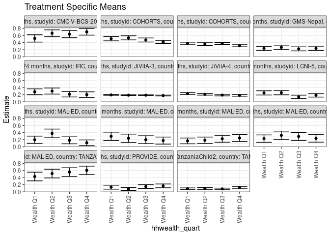

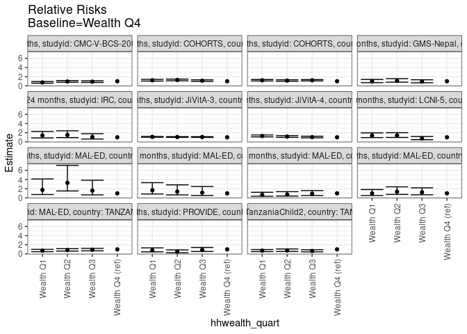

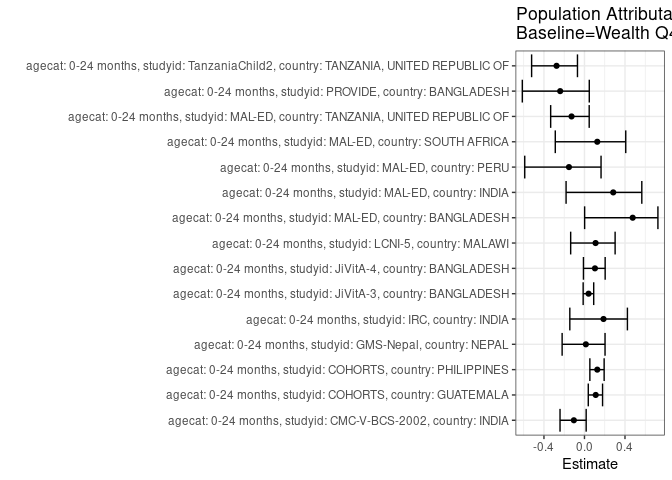

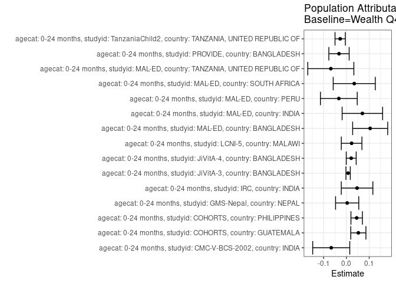

## Results Table

### Parameter: TSM

| agecat | studyid | country | intervention_level | baseline_level | estimate | ci_lower | ci_upper |
| --- | --- | --- | --- | --- | --- | --- | --- |
| 0-24 months | CMC-V-BCS-2002 | INDIA | Wealth Q4 | NA | 0.7019670 | 0.6096008 | 0.7943332 |
| 0-24 months | CMC-V-BCS-2002 | INDIA | Wealth Q1 | NA | 0.5171267 | 0.4139657 | 0.6202877 |
| 0-24 months | CMC-V-BCS-2002 | INDIA | Wealth Q2 | NA | 0.6616413 | 0.5657400 | 0.7575427 |
| 0-24 months | CMC-V-BCS-2002 | INDIA | Wealth Q3 | NA | 0.6366929 | 0.5376623 | 0.7357234 |
| 0-24 months | COHORTS | GUATEMALA | Wealth Q4 | NA | 0.4201988 | 0.3773880 | 0.4630096 |
| 0-24 months | COHORTS | GUATEMALA | Wealth Q1 | NA | 0.5101085 | 0.4495378 | 0.5706793 |
| 0-24 months | COHORTS | GUATEMALA | Wealth Q2 | NA | 0.5336641 | 0.4761147 | 0.5912134 |
| 0-24 months | COHORTS | GUATEMALA | Wealth Q3 | NA | 0.4732243 | 0.4166107 | 0.5298380 |
| 0-24 months | COHORTS | PHILIPPINES | Wealth Q4 | NA | 0.3111672 | 0.2822199 | 0.3401145 |
| 0-24 months | COHORTS | PHILIPPINES | Wealth Q1 | NA | 0.3758151 | 0.3395469 | 0.4120834 |
| 0-24 months | COHORTS | PHILIPPINES | Wealth Q2 | NA | 0.3570438 | 0.3178883 | 0.3961993 |
| 0-24 months | COHORTS | PHILIPPINES | Wealth Q3 | NA | 0.3752064 | 0.3457993 | 0.4046135 |
| 0-24 months | GMS-Nepal | NEPAL | Wealth Q4 | NA | 0.2387936 | 0.1788663 | 0.2987208 |
| 0-24 months | GMS-Nepal | NEPAL | Wealth Q1 | NA | 0.2354378 | 0.1756879 | 0.2951877 |
| 0-24 months | GMS-Nepal | NEPAL | Wealth Q2 | NA | 0.2660993 | 0.2035348 | 0.3286639 |
| 0-24 months | GMS-Nepal | NEPAL | Wealth Q3 | NA | 0.2236613 | 0.1673468 | 0.2799758 |
| 0-24 months | IRC | INDIA | Wealth Q4 | NA | 0.2020246 | 0.1229299 | 0.2811193 |
| 0-24 months | IRC | INDIA | Wealth Q1 | NA | 0.2823636 | 0.1995657 | 0.3651615 |
| 0-24 months | IRC | INDIA | Wealth Q2 | NA | 0.3031526 | 0.2176968 | 0.3886084 |
| 0-24 months | IRC | INDIA | Wealth Q3 | NA | 0.2125746 | 0.1365505 | 0.2885987 |
| 0-24 months | JiVitA-3 | BANGLADESH | Wealth Q4 | NA | 0.1770770 | 0.1655830 | 0.1885711 |
| 0-24 months | JiVitA-3 | BANGLADESH | Wealth Q1 | NA | 0.1936641 | 0.1829301 | 0.2043981 |
| 0-24 months | JiVitA-3 | BANGLADESH | Wealth Q2 | NA | 0.1867636 | 0.1774630 | 0.1960642 |
| 0-24 months | JiVitA-3 | BANGLADESH | Wealth Q3 | NA | 0.1867956 | 0.1782834 | 0.1953078 |
| 0-24 months | JiVitA-4 | BANGLADESH | Wealth Q4 | NA | 0.1824132 | 0.1583548 | 0.2064716 |
| 0-24 months | JiVitA-4 | BANGLADESH | Wealth Q1 | NA | 0.2334916 | 0.2098566 | 0.2571266 |
| 0-24 months | JiVitA-4 | BANGLADESH | Wealth Q2 | NA | 0.2113430 | 0.1879880 | 0.2346980 |
| 0-24 months | JiVitA-4 | BANGLADESH | Wealth Q3 | NA | 0.1892304 | 0.1673880 | 0.2110728 |
| 0-24 months | LCNI-5 | MALAWI | Wealth Q4 | NA | 0.1852447 | 0.1331357 | 0.2373537 |
| 0-24 months | LCNI-5 | MALAWI | Wealth Q1 | NA | 0.2513946 | 0.1912790 | 0.3115102 |
| 0-24 months | LCNI-5 | MALAWI | Wealth Q2 | NA | 0.2577386 | 0.1973313 | 0.3181459 |
| 0-24 months | LCNI-5 | MALAWI | Wealth Q3 | NA | 0.1388498 | 0.0907359 | 0.1869636 |
| 0-24 months | MAL-ED | BANGLADESH | Wealth Q4 | NA | 0.1147541 | 0.0346050 | 0.1949032 |
| 0-24 months | MAL-ED | BANGLADESH | Wealth Q1 | NA | 0.2000000 | 0.0985781 | 0.3014219 |
| 0-24 months | MAL-ED | BANGLADESH | Wealth Q2 | NA | 0.3770492 | 0.2551760 | 0.4989224 |
| 0-24 months | MAL-ED | BANGLADESH | Wealth Q3 | NA | 0.1833333 | 0.0852230 | 0.2814437 |
| 0-24 months | MAL-ED | INDIA | Wealth Q4 | NA | 0.1767445 | 0.0774269 | 0.2760621 |
| 0-24 months | MAL-ED | INDIA | Wealth Q1 | NA | 0.2963432 | 0.1792323 | 0.4134541 |
| 0-24 months | MAL-ED | INDIA | Wealth Q2 | NA | 0.2412912 | 0.1249541 | 0.3576282 |
| 0-24 months | MAL-ED | INDIA | Wealth Q3 | NA | 0.2008586 | 0.0899868 | 0.3117304 |
| 0-24 months | MAL-ED | PERU | Wealth Q4 | NA | 0.2501217 | 0.1515527 | 0.3486907 |
| 0-24 months | MAL-ED | PERU | Wealth Q1 | NA | 0.1669797 | 0.0851752 | 0.2487842 |
| 0-24 months | MAL-ED | PERU | Wealth Q2 | NA | 0.1861574 | 0.0970685 | 0.2752463 |
| 0-24 months | MAL-ED | PERU | Wealth Q3 | NA | 0.2272909 | 0.1301868 | 0.3243951 |
| 0-24 months | MAL-ED | SOUTH AFRICA | Wealth Q4 | NA | 0.2379642 | 0.1321207 | 0.3438076 |
| 0-24 months | MAL-ED | SOUTH AFRICA | Wealth Q1 | NA | 0.2312689 | 0.1274197 | 0.3351181 |
| 0-24 months | MAL-ED | SOUTH AFRICA | Wealth Q2 | NA | 0.3229737 | 0.2046361 | 0.4413114 |
| 0-24 months | MAL-ED | SOUTH AFRICA | Wealth Q3 | NA | 0.2921413 | 0.1803333 | 0.4039492 |
| 0-24 months | MAL-ED | TANZANIA, UNITED REPUBLIC OF | Wealth Q4 | NA | 0.6044086 | 0.4867843 | 0.7220328 |
| 0-24 months | MAL-ED | TANZANIA, UNITED REPUBLIC OF | Wealth Q1 | NA | 0.4306020 | 0.3084219 | 0.5527822 |
| 0-24 months | MAL-ED | TANZANIA, UNITED REPUBLIC OF | Wealth Q2 | NA | 0.5137191 | 0.3912218 | 0.6362163 |
| 0-24 months | MAL-ED | TANZANIA, UNITED REPUBLIC OF | Wealth Q3 | NA | 0.5553390 | 0.4350481 | 0.6756298 |
| 0-24 months | PROVIDE | BANGLADESH | Wealth Q4 | NA | 0.1682553 | 0.1146534 | 0.2218571 |
| 0-24 months | PROVIDE | BANGLADESH | Wealth Q1 | NA | 0.1310625 | 0.0757150 | 0.1864099 |
| 0-24 months | PROVIDE | BANGLADESH | Wealth Q2 | NA | 0.0814416 | 0.0400022 | 0.1228810 |
| 0-24 months | PROVIDE | BANGLADESH | Wealth Q3 | NA | 0.1473817 | 0.0936821 | 0.2010813 |
| 0-24 months | TanzaniaChild2 | TANZANIA, UNITED REPUBLIC OF | Wealth Q4 | NA | 0.1268095 | 0.0997840 | 0.1538349 |
| 0-24 months | TanzaniaChild2 | TANZANIA, UNITED REPUBLIC OF | Wealth Q1 | NA | 0.0900735 | 0.0694871 | 0.1106599 |
| 0-24 months | TanzaniaChild2 | TANZANIA, UNITED REPUBLIC OF | Wealth Q2 | NA | 0.0969022 | 0.0703270 | 0.1234775 |
| 0-24 months | TanzaniaChild2 | TANZANIA, UNITED REPUBLIC OF | Wealth Q3 | NA | 0.0825906 | 0.0601958 | 0.1049854 |

### Parameter: E(Y)

| agecat | studyid | country | intervention_level | baseline_level | estimate | ci_lower | ci_upper |
| --- | --- | --- | --- | --- | --- | --- | --- |
| 0-24 months | CMC-V-BCS-2002 | INDIA | NA | NA | 0.6353887 | 0.5864772 | 0.6843003 |
| 0-24 months | COHORTS | GUATEMALA | NA | NA | 0.4726135 | 0.4452311 | 0.4999958 |
| 0-24 months | COHORTS | PHILIPPINES | NA | NA | 0.3562316 | 0.3392530 | 0.3732102 |
| 0-24 months | GMS-Nepal | NEPAL | NA | NA | 0.2421203 | 0.2103189 | 0.2739218 |
| 0-24 months | IRC | INDIA | NA | NA | 0.2487805 | 0.2068840 | 0.2906770 |
| 0-24 months | JiVitA-3 | BANGLADESH | NA | NA | 0.1845385 | 0.1789329 | 0.1901441 |
| 0-24 months | JiVitA-4 | BANGLADESH | NA | NA | 0.2034648 | 0.1916516 | 0.2152780 |
| 0-24 months | LCNI-5 | MALAWI | NA | NA | 0.2080783 | 0.1802263 | 0.2359304 |
| 0-24 months | MAL-ED | BANGLADESH | NA | NA | 0.2190083 | 0.1667935 | 0.2712230 |
| 0-24 months | MAL-ED | INDIA | NA | NA | 0.2468085 | 0.1915661 | 0.3020510 |
| 0-24 months | MAL-ED | PERU | NA | NA | 0.2169118 | 0.1678424 | 0.2659811 |
| 0-24 months | MAL-ED | SOUTH AFRICA | NA | NA | 0.2723735 | 0.2178399 | 0.3269072 |
| 0-24 months | MAL-ED | TANZANIA, UNITED REPUBLIC OF | NA | NA | 0.5360000 | 0.4740573 | 0.5979427 |
| 0-24 months | PROVIDE | BANGLADESH | NA | NA | 0.1357143 | 0.1103250 | 0.1611036 |
| 0-24 months | TanzaniaChild2 | TANZANIA, UNITED REPUBLIC OF | NA | NA | 0.0994128 | 0.0873992 | 0.1114263 |

### Parameter: RR

| agecat | studyid | country | intervention_level | baseline_level | estimate | ci_lower | ci_upper |
| --- | --- | --- | --- | --- | --- | --- | --- |
| 0-24 months | CMC-V-BCS-2002 | INDIA | Wealth Q4 | Wealth Q4 | 1.0000000 | 1.0000000 | 1.0000000 |
| 0-24 months | CMC-V-BCS-2002 | INDIA | Wealth Q1 | Wealth Q4 | 0.7366824 | 0.5799593 | 0.9357570 |
| 0-24 months | CMC-V-BCS-2002 | INDIA | Wealth Q2 | Wealth Q4 | 0.9425534 | 0.7750675 | 1.1462317 |
| 0-24 months | CMC-V-BCS-2002 | INDIA | Wealth Q3 | Wealth Q4 | 0.9070126 | 0.7396916 | 1.1121822 |
| 0-24 months | COHORTS | GUATEMALA | Wealth Q4 | Wealth Q4 | 1.0000000 | 1.0000000 | 1.0000000 |
| 0-24 months | COHORTS | GUATEMALA | Wealth Q1 | Wealth Q4 | 1.2139695 | 1.0406893 | 1.4161017 |
| 0-24 months | COHORTS | GUATEMALA | Wealth Q2 | Wealth Q4 | 1.2700275 | 1.0984986 | 1.4683405 |
| 0-24 months | COHORTS | GUATEMALA | Wealth Q3 | Wealth Q4 | 1.1261914 | 0.9651781 | 1.3140654 |
| 0-24 months | COHORTS | PHILIPPINES | Wealth Q4 | Wealth Q4 | 1.0000000 | 1.0000000 | 1.0000000 |
| 0-24 months | COHORTS | PHILIPPINES | Wealth Q1 | Wealth Q4 | 1.2077594 | 1.0590091 | 1.3774033 |
| 0-24 months | COHORTS | PHILIPPINES | Wealth Q2 | Wealth Q4 | 1.1474338 | 0.9967908 | 1.3208431 |
| 0-24 months | COHORTS | PHILIPPINES | Wealth Q3 | Wealth Q4 | 1.2058031 | 1.0711713 | 1.3573564 |
| 0-24 months | GMS-Nepal | NEPAL | Wealth Q4 | Wealth Q4 | 1.0000000 | 1.0000000 | 1.0000000 |
| 0-24 months | GMS-Nepal | NEPAL | Wealth Q1 | Wealth Q4 | 0.9859471 | 0.6952260 | 1.3982384 |
| 0-24 months | GMS-Nepal | NEPAL | Wealth Q2 | Wealth Q4 | 1.1143489 | 0.7948740 | 1.5622268 |
| 0-24 months | GMS-Nepal | NEPAL | Wealth Q3 | Wealth Q4 | 0.9366302 | 0.6621207 | 1.3249491 |
| 0-24 months | IRC | INDIA | Wealth Q4 | Wealth Q4 | 1.0000000 | 1.0000000 | 1.0000000 |
| 0-24 months | IRC | INDIA | Wealth Q1 | Wealth Q4 | 1.3976693 | 0.8602257 | 2.2708917 |
| 0-24 months | IRC | INDIA | Wealth Q2 | Wealth Q4 | 1.5005725 | 0.9318283 | 2.4164516 |
| 0-24 months | IRC | INDIA | Wealth Q3 | Wealth Q4 | 1.0522212 | 0.6223649 | 1.7789716 |
| 0-24 months | JiVitA-3 | BANGLADESH | Wealth Q4 | Wealth Q4 | 1.0000000 | 1.0000000 | 1.0000000 |
| 0-24 months | JiVitA-3 | BANGLADESH | Wealth Q1 | Wealth Q4 | 1.0936712 | 1.0122657 | 1.1816233 |
| 0-24 months | JiVitA-3 | BANGLADESH | Wealth Q2 | Wealth Q4 | 1.0547026 | 0.9803065 | 1.1347447 |
| 0-24 months | JiVitA-3 | BANGLADESH | Wealth Q3 | Wealth Q4 | 1.0548832 | 0.9845770 | 1.1302098 |
| 0-24 months | JiVitA-4 | BANGLADESH | Wealth Q4 | Wealth Q4 | 1.0000000 | 1.0000000 | 1.0000000 |
| 0-24 months | JiVitA-4 | BANGLADESH | Wealth Q1 | Wealth Q4 | 1.2800147 | 1.0914642 | 1.5011373 |
| 0-24 months | JiVitA-4 | BANGLADESH | Wealth Q2 | Wealth Q4 | 1.1585946 | 0.9828617 | 1.3657479 |
| 0-24 months | JiVitA-4 | BANGLADESH | Wealth Q3 | Wealth Q4 | 1.0373719 | 0.8781680 | 1.2254380 |
| 0-24 months | LCNI-5 | MALAWI | Wealth Q4 | Wealth Q4 | 1.0000000 | 1.0000000 | 1.0000000 |
| 0-24 months | LCNI-5 | MALAWI | Wealth Q1 | Wealth Q4 | 1.3570951 | 0.9380963 | 1.9632389 |
| 0-24 months | LCNI-5 | MALAWI | Wealth Q2 | Wealth Q4 | 1.3913414 | 0.9644646 | 2.0071559 |
| 0-24 months | LCNI-5 | MALAWI | Wealth Q3 | Wealth Q4 | 0.7495479 | 0.4801038 | 1.1702095 |
| 0-24 months | MAL-ED | BANGLADESH | Wealth Q4 | Wealth Q4 | 1.0000000 | 1.0000000 | 1.0000000 |
| 0-24 months | MAL-ED | BANGLADESH | Wealth Q1 | Wealth Q4 | 1.7428571 | 0.7352116 | 4.1315329 |
| 0-24 months | MAL-ED | BANGLADESH | Wealth Q2 | Wealth Q4 | 3.2857143 | 1.5219238 | 7.0935998 |
| 0-24 months | MAL-ED | BANGLADESH | Wealth Q3 | Wealth Q4 | 1.5976190 | 0.6627391 | 3.8512693 |
| 0-24 months | MAL-ED | INDIA | Wealth Q4 | Wealth Q4 | 1.0000000 | 1.0000000 | 1.0000000 |
| 0-24 months | MAL-ED | INDIA | Wealth Q1 | Wealth Q4 | 1.6766756 | 0.8452427 | 3.3259574 |
| 0-24 months | MAL-ED | INDIA | Wealth Q2 | Wealth Q4 | 1.3651976 | 0.6550792 | 2.8450979 |
| 0-24 months | MAL-ED | INDIA | Wealth Q3 | Wealth Q4 | 1.1364349 | 0.5198114 | 2.4845244 |
| 0-24 months | MAL-ED | PERU | Wealth Q4 | Wealth Q4 | 1.0000000 | 1.0000000 | 1.0000000 |
| 0-24 months | MAL-ED | PERU | Wealth Q1 | Wealth Q4 | 0.6675937 | 0.3619056 | 1.2314852 |
| 0-24 months | MAL-ED | PERU | Wealth Q2 | Wealth Q4 | 0.7442672 | 0.4071932 | 1.3603708 |
| 0-24 months | MAL-ED | PERU | Wealth Q3 | Wealth Q4 | 0.9087213 | 0.5172381 | 1.5965074 |
| 0-24 months | MAL-ED | SOUTH AFRICA | Wealth Q4 | Wealth Q4 | 1.0000000 | 1.0000000 | 1.0000000 |
| 0-24 months | MAL-ED | SOUTH AFRICA | Wealth Q1 | Wealth Q4 | 0.9718644 | 0.5178642 | 1.8238766 |
| 0-24 months | MAL-ED | SOUTH AFRICA | Wealth Q2 | Wealth Q4 | 1.3572367 | 0.7632333 | 2.4135364 |
| 0-24 months | MAL-ED | SOUTH AFRICA | Wealth Q3 | Wealth Q4 | 1.2276691 | 0.6836804 | 2.2044970 |
| 0-24 months | MAL-ED | TANZANIA, UNITED REPUBLIC OF | Wealth Q4 | Wealth Q4 | 1.0000000 | 1.0000000 | 1.0000000 |
| 0-24 months | MAL-ED | TANZANIA, UNITED REPUBLIC OF | Wealth Q1 | Wealth Q4 | 0.7124354 | 0.5067498 | 1.0016071 |
| 0-24 months | MAL-ED | TANZANIA, UNITED REPUBLIC OF | Wealth Q2 | Wealth Q4 | 0.8499533 | 0.6268540 | 1.1524544 |
| 0-24 months | MAL-ED | TANZANIA, UNITED REPUBLIC OF | Wealth Q3 | Wealth Q4 | 0.9188139 | 0.6895307 | 1.2243384 |
| 0-24 months | PROVIDE | BANGLADESH | Wealth Q4 | Wealth Q4 | 1.0000000 | 1.0000000 | 1.0000000 |
| 0-24 months | PROVIDE | BANGLADESH | Wealth Q1 | Wealth Q4 | 0.7789502 | 0.4590126 | 1.3218883 |
| 0-24 months | PROVIDE | BANGLADESH | Wealth Q2 | Wealth Q4 | 0.4840359 | 0.2656530 | 0.8819429 |
| 0-24 months | PROVIDE | BANGLADESH | Wealth Q3 | Wealth Q4 | 0.8759412 | 0.5404782 | 1.4196187 |
| 0-24 months | TanzaniaChild2 | TANZANIA, UNITED REPUBLIC OF | Wealth Q4 | Wealth Q4 | 1.0000000 | 1.0000000 | 1.0000000 |
| 0-24 months | TanzaniaChild2 | TANZANIA, UNITED REPUBLIC OF | Wealth Q1 | Wealth Q4 | 0.7103056 | 0.5202086 | 0.9698687 |
| 0-24 months | TanzaniaChild2 | TANZANIA, UNITED REPUBLIC OF | Wealth Q2 | Wealth Q4 | 0.7641559 | 0.5402537 | 1.0808519 |
| 0-24 months | TanzaniaChild2 | TANZANIA, UNITED REPUBLIC OF | Wealth Q3 | Wealth Q4 | 0.6512968 | 0.4615655 | 0.9190192 |

### Parameter: PAR

| agecat | studyid | country | intervention_level | baseline_level | estimate | ci_lower | ci_upper |
| --- | --- | --- | --- | --- | --- | --- | --- |
| 0-24 months | CMC-V-BCS-2002 | INDIA | Wealth Q4 | NA | -0.0665782 | -0.1479027 | 0.0147462 |
| 0-24 months | COHORTS | GUATEMALA | Wealth Q4 | NA | 0.0524146 | 0.0192095 | 0.0856198 |
| 0-24 months | COHORTS | PHILIPPINES | Wealth Q4 | NA | 0.0450644 | 0.0198633 | 0.0702654 |
| 0-24 months | GMS-Nepal | NEPAL | Wealth Q4 | NA | 0.0033268 | -0.0475795 | 0.0542331 |
| 0-24 months | IRC | INDIA | Wealth Q4 | NA | 0.0467559 | -0.0225630 | 0.1160747 |
| 0-24 months | JiVitA-3 | BANGLADESH | Wealth Q4 | NA | 0.0074614 | -0.0021229 | 0.0170457 |
| 0-24 months | JiVitA-4 | BANGLADESH | Wealth Q4 | NA | 0.0210516 | -0.0007513 | 0.0428544 |
| 0-24 months | LCNI-5 | MALAWI | Wealth Q4 | NA | 0.0228337 | -0.0223913 | 0.0680586 |
| 0-24 months | MAL-ED | BANGLADESH | Wealth Q4 | NA | 0.1042542 | 0.0273661 | 0.1811422 |
| 0-24 months | MAL-ED | INDIA | Wealth Q4 | NA | 0.0700640 | -0.0187923 | 0.1589204 |
| 0-24 months | MAL-ED | PERU | Wealth Q4 | NA | -0.0332099 | -0.1139323 | 0.0475124 |
| 0-24 months | MAL-ED | SOUTH AFRICA | Wealth Q4 | NA | 0.0344094 | -0.0579389 | 0.1267576 |
| 0-24 months | MAL-ED | TANZANIA, UNITED REPUBLIC OF | Wealth Q4 | NA | -0.0684086 | -0.1694425 | 0.0326254 |
| 0-24 months | PROVIDE | BANGLADESH | Wealth Q4 | NA | -0.0325410 | -0.0771223 | 0.0120404 |
| 0-24 months | TanzaniaChild2 | TANZANIA, UNITED REPUBLIC OF | Wealth Q4 | NA | -0.0273967 | -0.0500001 | -0.0047933 |

### Parameter: PAF

| agecat | studyid | country | intervention_level | baseline_level | estimate | ci_lower | ci_upper |
| --- | --- | --- | --- | --- | --- | --- | --- |
| 0-24 months | CMC-V-BCS-2002 | INDIA | Wealth Q4 | NA | -0.1047834 | -0.2413075 | 0.0167251 |
| 0-24 months | COHORTS | GUATEMALA | Wealth Q4 | NA | 0.1109038 | 0.0375520 | 0.1786652 |
| 0-24 months | COHORTS | PHILIPPINES | Wealth Q4 | NA | 0.1265030 | 0.0531908 | 0.1941386 |
| 0-24 months | GMS-Nepal | NEPAL | Wealth Q4 | NA | 0.0137402 | -0.2206057 | 0.2030936 |
| 0-24 months | IRC | INDIA | Wealth Q4 | NA | 0.1879403 | -0.1446629 | 0.4238994 |
| 0-24 months | JiVitA-3 | BANGLADESH | Wealth Q4 | NA | 0.0404329 | -0.0130567 | 0.0910983 |
| 0-24 months | JiVitA-4 | BANGLADESH | Wealth Q4 | NA | 0.1034653 | -0.0100745 | 0.2042425 |
| 0-24 months | LCNI-5 | MALAWI | Wealth Q4 | NA | 0.1097359 | -0.1362856 | 0.3024903 |
| 0-24 months | MAL-ED | BANGLADESH | Wealth Q4 | NA | 0.4760285 | 0.0014882 | 0.7250446 |
| 0-24 months | MAL-ED | INDIA | Wealth Q4 | NA | 0.2838801 | -0.1815976 | 0.5659878 |
| 0-24 months | MAL-ED | PERU | Wealth Q4 | NA | -0.1531035 | -0.5897555 | 0.1636150 |
| 0-24 months | MAL-ED | SOUTH AFRICA | Wealth Q4 | NA | 0.1263315 | -0.2881944 | 0.4074679 |
| 0-24 months | MAL-ED | TANZANIA, UNITED REPUBLIC OF | Wealth Q4 | NA | -0.1276279 | -0.3337663 | 0.0466510 |
| 0-24 months | PROVIDE | BANGLADESH | Wealth Q4 | NA | -0.2397756 | -0.6136633 | 0.0474819 |
| 0-24 months | TanzaniaChild2 | TANZANIA, UNITED REPUBLIC OF | Wealth Q4 | NA | -0.2755857 | -0.5218764 | -0.0691531 |